# Human Activity Recognition

Beatriz Ortiz

20 Jun 2015

## Overview:

In this project, we will use data from accelerometers on the belt, forearm, arm, and dumbell of 6 participants. In this report that we will create later, we try to investigate “how (well)” an activity was performed by the wearer.

## Prepare the Enviroment

First, we are going to load the necesary libraries to generate code and plots and prepare the enviroment to use Knit options.

```r
library(caret)
```

```r
library(rpart)
library(rpart.plot)
library(rattle)
library(randomForest)
library(knitr)
opts_chunk$set(echo = TRUE, results = 'hold')
```

## DownLoad data.

Now we are going download data read csv files into training and test. Then we will go to prepprocess data using cross validation

```r
if (!file.exists("./har")){
        dir.create("./har")
        url1 <- "https://d396qusza40orc.cloudfront.net/predmachlearn/pml-training.csv"
        url2 <- "https://d396qusza40orc.cloudfront.net/predmachlearn/pml-testing.csv"
download.file(url,destfile="./har/pml-training.csv",method="curl")
download.file(url,destfile="./har/pml-testing.csv",method="curl")
}

training <- read.csv("./har/pml-training.csv")
test <- read.csv("./har/pml-testing.csv")
```

### Spliting the trainig set

Now we will use the function createDataPartition to create balanced splits of the trainig set. We will create a 60/40% split of the data. Previously we set a seed.

```r
set.seed(8420)
trainIndex <- createDataPartition(training$classe, p = 0.6,  list = FALSE)
train_part <- training[trainIndex, ]
test_part  <- training[-trainIndex, ]
dim(train_part)
dim(test_part)
```

```
## [1] 11776   160
## [1] 7846  160
```

## Cleaning and pre-Processing Data

### Near Zero Covariate

Prior to modeling, we want to identify and eliminate columns with a few unique numeric values. To do this, we use the neaZeroValues function:

```r
nzv <- nearZeroVar(train_part , saveMetrics= TRUE)
nzv <- nearZeroVar(train_part)
train_part <- train_part[, -nzv]
```

Now, we want to know in which columns there are missing values and the total number in each column. We will remove those, whose values are mostly NA

```r
 colSums(is.na(train_part))
```

```
##                        X                user_name     raw_timestamp_part_1
##                        0                        0                        0
##     raw_timestamp_part_2           cvtd_timestamp               num_window
##                        0                        0                        0
##                roll_belt               pitch_belt                 yaw_belt
##                        0                        0                        0
##         total_accel_belt            max_roll_belt           max_picth_belt
##                        0                    11525                    11525
##            min_roll_belt           min_pitch_belt      amplitude_roll_belt
##                    11525                    11525                    11525
##     amplitude_pitch_belt     var_total_accel_belt            avg_roll_belt
##                    11525                    11525                    11525
##         stddev_roll_belt            var_roll_belt           avg_pitch_belt
##                    11525                    11525                    11525
##        stddev_pitch_belt           var_pitch_belt             avg_yaw_belt
##                    11525                    11525                    11525
##          stddev_yaw_belt             var_yaw_belt             gyros_belt_x
##                    11525                    11525                        0
##             gyros_belt_y             gyros_belt_z             accel_belt_x
##                        0                        0                        0
##             accel_belt_y             accel_belt_z            magnet_belt_x
##                        0                        0                        0
##            magnet_belt_y            magnet_belt_z                 roll_arm
##                        0                        0                        0
##                pitch_arm                  yaw_arm          total_accel_arm
##                        0                        0                        0
##            var_accel_arm              gyros_arm_x              gyros_arm_y
##                    11525                        0                        0
##              gyros_arm_z              accel_arm_x              accel_arm_y
##                        0                        0                        0
##              accel_arm_z             magnet_arm_x             magnet_arm_y
##                        0                        0                        0
##             magnet_arm_z             max_roll_arm            max_picth_arm
##                        0                    11525                    11525
##              max_yaw_arm             min_roll_arm            min_pitch_arm
##                    11525                    11525                    11525
##              min_yaw_arm       amplitude_roll_arm      amplitude_pitch_arm
##                    11525                    11525                    11525
##        amplitude_yaw_arm            roll_dumbbell           pitch_dumbbell
##                    11525                        0                        0
```

[output cut: 17 more lines]

```
##                        0                        0                        0
##             roll_forearm            pitch_forearm              yaw_forearm
##                        0                        0                        0
##         max_roll_forearm        max_picth_forearm         min_roll_forearm
##                    11525                    11525                    11525
##        min_pitch_forearm  amplitude_pitch_forearm      total_accel_forearm
##                    11525                    11525                        0
##        var_accel_forearm          gyros_forearm_x          gyros_forearm_y
##                    11525                        0                        0
##          gyros_forearm_z          accel_forearm_x          accel_forearm_y
##                        0                        0                        0
##          accel_forearm_z         magnet_forearm_x         magnet_forearm_y
##                        0                        0                        0
##         magnet_forearm_z                   classe
##                        0                        0
```

As we can see, all the columns with missing values, have more than a 90% of this NA. I will go to remove then.

```r
 train_part <- train_part[ ,(colSums(is.na(train_part)) == 0)]
```

```r
 train_part <- train_part[ ,-c(1:5)]
 str(train_part)
```

```
## 'data.frame':    11776 obs. of  54 variables:
##  $ num_window          : int  11 11 12 12 12 12 12 12 12 12 ...
##  $ roll_belt           : num  1.41 1.42 1.48 1.45 1.42 1.42 1.43 1.45 1.43 1.45 ...
##  $ pitch_belt          : num  8.07 8.07 8.07 8.06 8.09 8.13 8.16 8.18 8.18 8.2 ...
##  $ yaw_belt            : num  -94.4 -94.4 -94.4 -94.4 -94.4 -94.4 -94.4 -94.4 -94.4 -94.4 ...
##  $ total_accel_belt    : int  3 3 3 3 3 3 3 3 3 3 ...
##  $ gyros_belt_x        : num  0.02 0 0.02 0.02 0.02 0.02 0.02 0.03 0.02 0 ...
##  $ gyros_belt_y        : num  0 0 0.02 0 0 0 0 0 0 0 ...
##  $ gyros_belt_z        : num  -0.02 -0.02 -0.02 -0.02 -0.02 -0.02 -0.02 -0.02 -0.02 0 ...
##  $ accel_belt_x        : int  -22 -20 -21 -21 -22 -22 -20 -21 -22 -21 ...
##  $ accel_belt_y        : int  4 5 2 4 3 4 2 2 2 2 ...
##  $ accel_belt_z        : int  22 23 24 21 21 21 24 23 23 22 ...
##  $ magnet_belt_x       : int  -7 -2 -6 0 -4 -2 1 -5 -2 -1 ...
##  $ magnet_belt_y       : int  608 600 600 603 599 603 602 596 602 597 ...
##  $ magnet_belt_z       : int  -311 -305 -302 -312 -311 -313 -312 -317 -319 -310 ...
```

[output cut: 40 more lines]

Clean now the test_part and test set

```r
trcolnames <- colnames(train_part)
trcolnames2 <- colnames(train_part[ ,-54])

test_part <- test_part[trcolnames]
test <- test[trcolnames2]
```

## Cross Validation

I will use trainControl functionc to specifiy the type of resampling. I will specifie 10-fold repeated cross-validation with repeated 3 times. Then I will pass this value directly to the train function as an argument .

```r
fitControl <- trainControl(method = "repeatedcv",
                            number = 10,
                           repeats = 3)
```

### Modeling

Now we are going to fit a model using classe variable as outcome value. First I use rpart method. We pass fitControl as argument.

```r
modelFit <- train(classe ~ ., data = train_part,
                  method = "rpart",
                 trControl = fitControl)
print(modelFit)
```

```
## CART
##
## 11776 samples
##    53 predictor
##     5 classes: 'A', 'B', 'C', 'D', 'E'
##
## No pre-processing
## Resampling: Cross-Validated (10 fold, repeated 3 times)
##
## Summary of sample sizes: 10599, 10599, 10597, 10598, 10599, 10599, ...
##
## Resampling results across tuning parameters:
##
##   cp          Accuracy   Kappa       Accuracy SD  Kappa SD
##   0.03945183  0.5244863  0.38984214  0.03046431   0.04864015
##   0.05908875  0.4277555  0.22882576  0.06116588   0.10359572
##   0.11675368  0.3348298  0.07699313  0.03929196   0.05975369
##
## Accuracy was used to select the optimal model using  the largest value.
## The final value used for the model was cp = 0.03945183.
```

And this is the Plot for modelFit

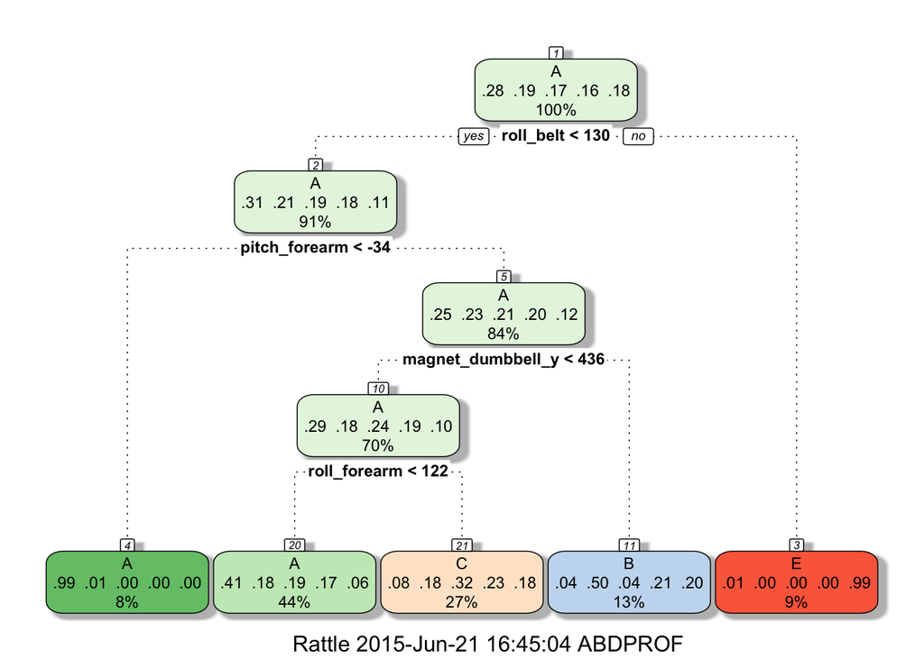

```r
fancyRpartPlot(modelFit$finalModel)
```

Now we are going to predict against to the test_part set. we evaluate our model results through confusion Matrix.

```r
prediction <- predict(modelFit, newdata=test_part)
confusionMatrix(prediction, test_part$classe)
```

```
## Confusion Matrix and Statistics
##
##           Reference
## Prediction    A    B    C    D    E
##          A 2037  622  623  557  228
##          B   42  519   44  247  179
##          C  149  377  701  482  398
##          D    0    0    0    0    0
##          E    4    0    0    0  637
##
## Overall Statistics
##
##                Accuracy : 0.4963
##                  95% CI : (0.4852, 0.5074)
##     No Information Rate : 0.2845
##     P-Value [Acc > NIR] : < 2.2e-16
##
##                   Kappa : 0.3418
##  Mcnemar's Test P-Value : NA
##
## Statistics by Class:
##
##                      Class: A Class: B Class: C Class: D Class: E
## Sensitivity            0.9126  0.34190  0.51243   0.0000  0.44175
## Specificity            0.6384  0.91909  0.78296   1.0000  0.99938
## Pos Pred Value         0.5009  0.50339  0.33270      NaN  0.99376
## Neg Pred Value         0.9484  0.85341  0.88378   0.8361  0.88827
## Prevalence             0.2845  0.19347  0.17436   0.1639  0.18379
## Detection Rate         0.2596  0.06615  0.08934   0.0000  0.08119
## Detection Prevalence   0.5184  0.13140  0.26854   0.0000  0.08170
## Balanced Accuracy      0.7755  0.63049  0.64769   0.5000  0.72056
```

The algorithm fit a model with accuracy 0.4963. This is a bad and low value. Wi wil tray to fit a new model using Random Forest method.

## Prediction with Random Forest

```r
modelFit2 <- train(classe ~ ., data = train_part,
                  method = "rf",
                 trControl = fitControl)
print(modelFit2)
```

```
## Random Forest
##
## 11776 samples
##    53 predictor
##     5 classes: 'A', 'B', 'C', 'D', 'E'
##
## No pre-processing
## Resampling: Cross-Validated (10 fold, repeated 3 times)
##
## Summary of sample sizes: 10599, 10598, 10598, 10599, 10597, 10597, ...
##
## Resampling results across tuning parameters:
##
##   mtry  Accuracy   Kappa      Accuracy SD  Kappa SD
##    2    0.9928952  0.9910116  0.002717415  0.003438933
##   27    0.9966033  0.9957033  0.001623318  0.002053667
##   53    0.9921030  0.9900102  0.003944680  0.004991049
##
## Accuracy was used to select the optimal model using  the largest value.
## The final value used for the model was mtry = 27.
```

```r
prediction2 <- predict(modelFit2, newdata=test_part)
confusionMatrix(prediction2, test_part$classe)
```

```
## Confusion Matrix and Statistics
##
##           Reference
## Prediction    A    B    C    D    E
##          A 2230    8    0    0    0
##          B    1 1508    1    0    0
##          C    0    1 1367    6    0
##          D    0    1    0 1280    0
##          E    1    0    0    0 1442
##
## Overall Statistics
##
##                Accuracy : 0.9976
##                  95% CI : (0.9962, 0.9985)
##     No Information Rate : 0.2845
##     P-Value [Acc > NIR] : < 2.2e-16
##
##                   Kappa : 0.9969
##  Mcnemar's Test P-Value : NA
##
## Statistics by Class:
##
##                      Class: A Class: B Class: C Class: D Class: E
## Sensitivity            0.9991   0.9934   0.9993   0.9953   1.0000
## Specificity            0.9986   0.9997   0.9989   0.9998   0.9998
## Pos Pred Value         0.9964   0.9987   0.9949   0.9992   0.9993
## Neg Pred Value         0.9996   0.9984   0.9998   0.9991   1.0000
## Prevalence             0.2845   0.1935   0.1744   0.1639   0.1838
## Detection Rate         0.2842   0.1922   0.1742   0.1631   0.1838
## Detection Prevalence   0.2852   0.1925   0.1751   0.1633   0.1839
## Balanced Accuracy      0.9988   0.9965   0.9991   0.9976   0.9999
```

## Predit with real test set

Finally, we are going to predict the new values in the testing csv provided

```r
prediction3 <- predict(modelFit2, newdata=test)
```

```r
pml_write_files = function(x){
  n = length(x)
  for(i in 1:n){
    filename = paste0("problem_id_",i,".txt")
    write.table(x[i],file=filename,quote=FALSE,row.names=FALSE,col.names=FALSE)
  }
}

pml_write_files(prediction3)
```

## Conclusion

We get this prediction appling the model against test set:

```r
print(prediction3)
```

```
##  [1] B A B A A E D B A A B C B A E E A B B B
## Levels: A B C D E
```